# Máquinas de Vectores de Soporte — Predicción de Estrés Adolescente

Dataset: Teen Mental Health (stress_level como variable objetivo)

Zulema Luque Cornejo

15 de Mayo de 2026

# 1 Introducción

Este reporte aplica **Máquinas de Vectores de Soporte (SVM)** para predecir el **nivel de estrés** (`stress_level`, escala 1–10) en adolescentes a partir de variables relacionadas con el uso de redes sociales, sueño, rendimiento académico y salud mental.

# 2 Módulo 0: Librerías y configuración

```r
pkgs_requeridos <- c(
  "dplyr","tidyr","tibble","purrr","skimr","ggplot2","ggpubr",
  "readxl","tidymodels","e1071","kernlab",
  "randomForest","xgboost","doParallel","Metrics"
)

faltan <- pkgs_requeridos[!vapply(pkgs_requeridos, requireNamespace,
                                  logical(1), quietly = TRUE)]
if (length(faltan)) stop("Instala: install.packages(c(",
  paste0('"', faltan, '"', collapse = ", "), "))")

suppressPackageStartupMessages({
  library(dplyr);  library(tidyr);  library(tibble); library(purrr)
  library(skimr);  library(ggplot2); library(ggpubr)
  library(readxl); library(tidymodels)
  library(e1071);  library(kernlab)
  library(randomForest); library(xgboost)
  library(doParallel);   library(Metrics)
})

SEED <- 2024
set.seed(SEED)
cat("Semilla fijada:", SEED)
```

```
## Semilla fijada: 2024
```

# 3 Módulo 1: Carga, EDA y partición

## 3.1 Carga y preprocesamiento

```r
datos <- read_excel("datosestresyansiedad.xlsx",
                    sheet = "Teen_Mental_Health_Dataset")

# Codificación de variables categóricas a numéricas
datos <- datos %>%
  mutate(
    gender = as.integer(factor(gender)),
    platform_usage = as.integer(factor(platform_usage)),
    social_interaction_level = as.integer(factor(
      social_interaction_level, levels = c("low", "medium", "high")))
  )

cat(sprintf("Dimensiones: %d filas × %d columnas\n", nrow(datos), ncol(datos)))
```

```
## Dimensiones: 1200 filas × 13 columnas
```

```r
cat("Sin NA:", sum(is.na(datos)) == 0, "\n")
```

```
## Sin NA: TRUE
```

## 3.2 Resumen estadístico

```r
skim(datos)
```

Data summary

| Name | datos |
| --- | --- |
| Number of rows | 1200 |
| Number of columns | 13 |
| _______________________ |  |
| Column type frequency: |  |
| numeric | 13 |
| ________________________ |  |
| Group variables | None |

**Variable type: numeric**

| skim_variable | n_missing | complete_rate | mean | sd | p0 | p25 | p50 | p75 | p100 | hist |
| --- | --- | --- | --- | --- | --- | --- | --- | --- | --- | --- |
| age | 0 | 1 | 15.93 | 2.02 | 13.0 | 14.0 | 16.00 | 18.00 | 19 | ▇▅▃▃▇ |
| gender | 0 | 1 | 1.51 | 0.50 | 1.0 | 1.0 | 2.00 | 2.00 | 2 | ▇▁▁▁▇ |
| daily_social_media_hours | 0 | 1 | 4.54 | 2.03 | 1.0 | 2.8 | 4.50 | 6.30 | 8 | ▇▇▇▇▇ |
| platform_usage | 0 | 1 | 2.01 | 0.81 | 1.0 | 1.0 | 2.00 | 3.00 | 3 | ▇▁▇▁▇ |
| sleep_hours | 0 | 1 | 6.45 | 1.44 | 4.0 | 5.2 | 6.50 | 7.60 | 9 | ▇▇▇▇▆ |
| screen_time_before_sleep | 0 | 1 | 1.74 | 0.72 | 0.5 | 1.1 | 1.80 | 2.40 | 3 | ▇▇▇▇▆ |
| academic_performance | 0 | 1 | 2.99 | 0.58 | 2.0 | 2.5 | 2.99 | 3.48 | 4 | ▇▇▇▇▇ |
| physical_activity | 0 | 1 | 1.01 | 0.58 | 0.0 | 0.5 | 1.00 | 1.50 | 2 | ▇▆▇▇▇ |
| social_interaction_level | 0 | 1 | 1.96 | 0.81 | 1.0 | 1.0 | 2.00 | 3.00 | 3 | ▇▁▇▁▇ |
| anxiety_level | 0 | 1 | 5.64 | 2.86 | 1.0 | 3.0 | 6.00 | 8.00 | 10 | ▇▇▇▇▇ |
| addiction_level | 0 | 1 | 5.57 | 2.83 | 1.0 | 3.0 | 6.00 | 8.00 | 10 | ▇▇▇▇▇ |
| depression_label | 0 | 1 | 0.03 | 0.16 | 0.0 | 0.0 | 0.00 | 0.00 | 1 | ▇▁▁▁▁ |
| stress_level | 0 | 1 | 5.45 | 2.90 | 1.0 | 3.0 | 5.00 | 8.00 | 10 | ▇▇▇▆▇ |

## 3.3 Distribución de la variable objetivo

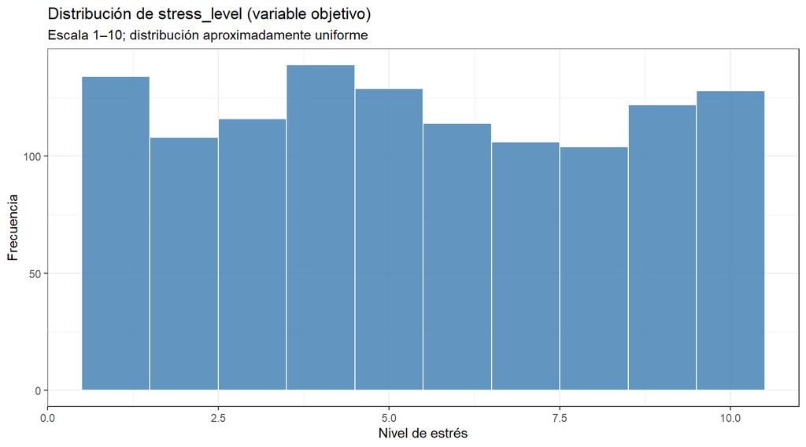

```r
ggplot(datos, aes(stress_level)) +
  geom_histogram(bins = 10, fill = "steelblue", color = "white", alpha = .85) +
  labs(title = "Distribución de stress_level (variable objetivo)",
       subtitle = "Escala 1–10; distribución aproximadamente uniforme",
       x = "Nivel de estrés", y = "Frecuencia") +
  theme_bw()
```

## 3.4 Matriz de correlaciones

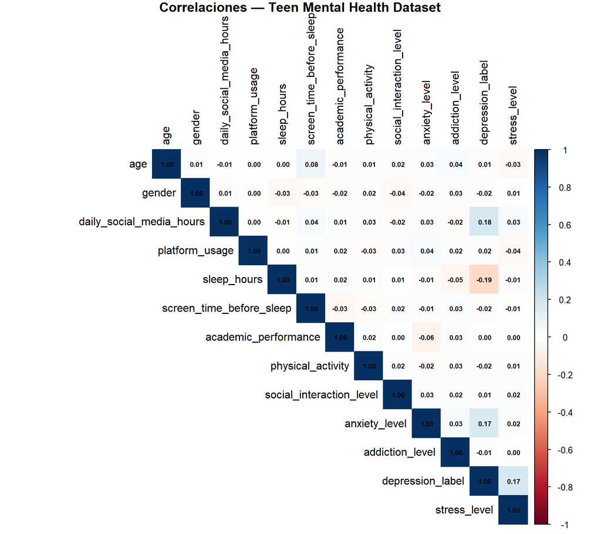

```r
if (requireNamespace("corrplot", quietly = TRUE)) {
  corrplot::corrplot(cor(datos), method = "color", type = "upper",
                     tl.col = "black", addCoef.col = "black", number.cex = 0.6,
                     title = "Correlaciones — Teen Mental Health Dataset",
                     mar = c(0,0,1,0))
} else {
  round(cor(datos), 2)
}
```

## 3.5 Partición estratificada 80/20

```r
set.seed(SEED)
split_obj  <- initial_split(datos, prop = 0.8, strata = stress_level)
data_train <- training(split_obj)
data_test  <- testing(split_obj)
y_train    <- data_train$stress_level
y_test     <- data_test$stress_level

cat(sprintf("Train: %d obs | Test: %d obs\n", nrow(data_train), nrow(data_test)))
```

```
## Train: 959 obs | Test: 241 obs
```

# 4 Módulo 2: SVM Lineal

El kernel lineal construye un hiperplano separador con margen máximo. Es el punto de partida para evaluar si la relación entre predictores y estrés es aproximadamente lineal.

```r
set.seed(SEED)
svm_lineal <- svm(stress_level ~ ., data = data_train,
                  kernel = "linear", cost = 1, scale = TRUE)

pred_lineal <- predict(svm_lineal, newdata = data_test)

cat(sprintf("SVM Lineal → RMSE: %.3f | MAE: %.3f | SV: %d (%.1f%%)\n",
            Metrics::rmse(y_test, pred_lineal),
            Metrics::mae (y_test, pred_lineal),
            svm_lineal$tot.nSV,
            100 * svm_lineal$tot.nSV / nrow(data_train)))
```

```
## SVM Lineal → RMSE: 2.942 | MAE: 2.494 | SV: 898 (93.6%)
```

> **Interpretación:** Un RMSE alto en SVM Lineal indicaría que la relación entre uso de redes sociales/sueño y el nivel de estrés no es capturada bien por un hiperplano lineal, justificando el uso de kernels no lineales.

# 5 Módulo 3: SVM Polinomial

Se prueban grados 2, 3 y 4 para capturar interacciones polinomiales entre las variables.

```r
resultados_poly <- data.frame()
for (d in c(2, 3, 4)) {
  set.seed(SEED)
  m <- svm(stress_level ~ ., data = data_train,
           kernel = "polynomial", degree = d,
           cost = 1, gamma = 0.1, coef0 = 0, scale = TRUE)
  p <- predict(m, newdata = data_test)
  resultados_poly <- rbind(resultados_poly,
                           data.frame(degree = d, SV = m$tot.nSV,
                                      RMSE = Metrics::rmse(y_test, p),
                                      MAE  = Metrics::mae (y_test, p)))
}
print(resultados_poly)
```

```
##   degree  SV     RMSE      MAE
## 1      2 893 3.069064 2.559992
## 2      3 892 3.617807 3.001109
## 3      4 907 3.365180 2.770786
```

```r
best_d    <- resultados_poly$degree[which.min(resultados_poly$RMSE)]
set.seed(SEED)
svm_poly  <- svm(stress_level ~ ., data = data_train,
                 kernel = "polynomial", degree = best_d,
                 cost = 1, gamma = 0.1, coef0 = 0, scale = TRUE)
pred_poly <- predict(svm_poly, newdata = data_test)
cat(sprintf("Mejor: grado %d → RMSE: %.3f | MAE: %.3f\n",
            best_d,
            Metrics::rmse(y_test, pred_poly),
            Metrics::mae (y_test, pred_poly)))
```

```
## Mejor: grado 2 → RMSE: 3.069 | MAE: 2.560
```

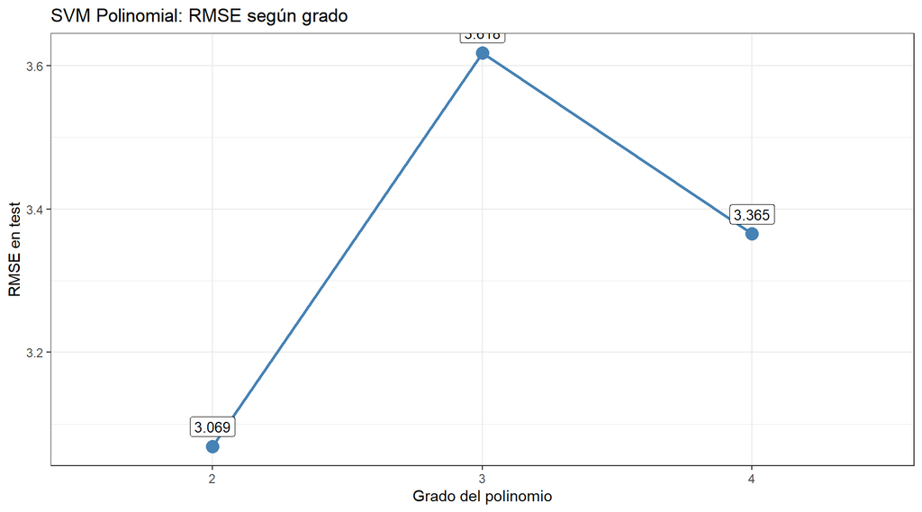

```r
ggplot(resultados_poly, aes(factor(degree), RMSE, group = 1)) +
  geom_line(color = "steelblue", linewidth = 1) +
  geom_point(size = 4, color = "steelblue") +
  geom_label(aes(label = round(RMSE, 3)), vjust = -0.5, size = 3.5) +
  labs(title = "SVM Polinomial: RMSE según grado",
       x = "Grado del polinomio", y = "RMSE en test") +
  theme_bw()
```

# 6 Módulo 4: SVM Radial base (RBF)

El kernel RBF (Radial Basis Function) es el más versátil y suele rendir mejor en datos no lineales. Se analiza la sensibilidad al parámetro γ.

```r
set.seed(SEED)
svm_radial_base <- svm(stress_level ~ ., data = data_train,
                       kernel = "radial",
                       cost  = 1,
                       gamma = 1 / ncol(data_train),
                       scale = TRUE)
pred_radial_base <- predict(svm_radial_base, newdata = data_test)

cat(sprintf("SVM Radial base → RMSE: %.3f | MAE: %.3f | SV: %d\n",
            Metrics::rmse(y_test, pred_radial_base),
            Metrics::mae (y_test, pred_radial_base),
            svm_radial_base$tot.nSV))
```

```
## SVM Radial base → RMSE: 3.161 | MAE: 2.646 | SV: 914
```

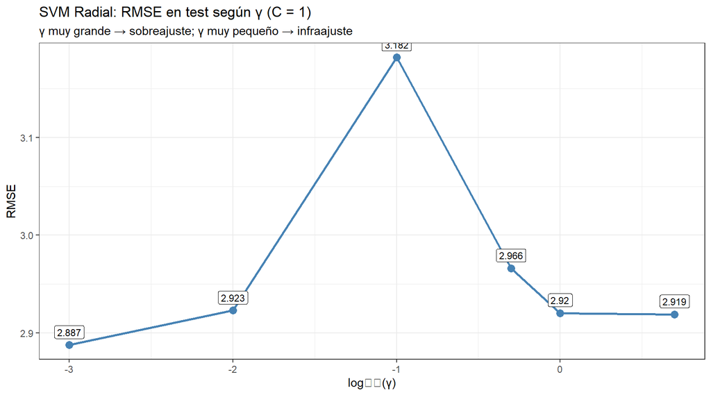

```r
gamma_range <- c(0.001, 0.01, 0.1, 0.5, 1, 5)
df_gamma <- map_dfr(gamma_range, function(g) {
  set.seed(SEED)
  m <- svm(stress_level ~ ., data = data_train,
           kernel = "radial", cost = 1, gamma = g, scale = TRUE)
  p <- predict(m, newdata = data_test)
  data.frame(gamma = g, RMSE = Metrics::rmse(y_test, p), SV = m$tot.nSV)
})

ggplot(df_gamma, aes(log10(gamma), RMSE)) +
  geom_line(color = "steelblue", linewidth = 1) +
  geom_point(size = 3, color = "steelblue") +
  geom_label(aes(label = round(RMSE, 3)), vjust = -0.5, size = 3) +
  labs(title = "SVM Radial: RMSE en test según γ (C = 1)",
       subtitle = "γ muy grande → sobreajuste; γ muy pequeño → infraajuste",
       x = "log₁₀(γ)", y = "RMSE") +
  theme_bw()
```

# 7 Módulo 5: SVM Radial tuneado con e1071

Búsqueda en rejilla con validación cruzada de 5 pliegues sobre C ∈ {0.1, 1, 5, 10, 50, 100} y γ ∈ {0.001, 0.01, 0.05, 0.1, 0.5}.

```r
set.seed(SEED)
tune_result <- tune(svm,
                    stress_level ~ .,
                    data   = data_train,
                    kernel = "radial",
                    scale  = TRUE,
                    ranges = list(
                      cost  = c(0.1, 1, 5, 10, 50, 100),
                      gamma = c(0.001, 0.01, 0.05, 0.1, 0.5)
                    ),
                    tunecontrol = tune.control(sampling = "cross", cross = 5))

cat(sprintf("Mejor C = %.3f | Mejor γ = %.4f | MSE CV = %.4f (RMSE ≈ %.4f)\n",
            tune_result$best.parameters$cost,
            tune_result$best.parameters$gamma,
            tune_result$best.performance,
            sqrt(tune_result$best.performance)))
```

```
## Mejor C = 0.100 | Mejor γ = 0.0100 | MSE CV = 8.2613 (RMSE ≈ 2.8742)
```

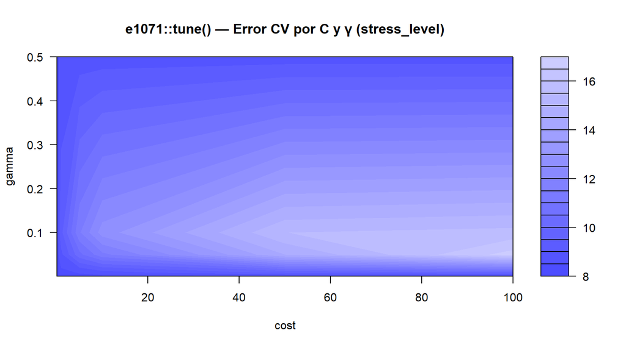

```r
plot(tune_result, main = "e1071::tune() — Error CV por C y γ (stress_level)")
```

```r
svm_radial_tuned  <- tune_result$best.model
pred_radial_tuned <- predict(svm_radial_tuned, newdata = data_test)

cat(sprintf("SVM Radial tuned → RMSE: %.3f | MAE: %.3f | SV: %d\n",
            Metrics::rmse(y_test, pred_radial_tuned),
            Metrics::mae (y_test, pred_radial_tuned),
            svm_radial_tuned$tot.nSV))
```

```
## SVM Radial tuned → RMSE: 2.889 | MAE: 2.470 | SV: 904
```

# 8 Módulo 6: SVM Radial con tidymodels

Búsqueda con latin hypercube (30 puntos), CV 5×3 y paralelización automática.

```r
receta_svm <- recipe(stress_level ~ ., data = data_train) %>%
  step_normalize(all_numeric_predictors())

svm_spec <- svm_rbf(mode = "regression", cost = tune(), rbf_sigma = tune()) %>%
  set_engine("kernlab")

wf_svm <- workflow() %>% add_recipe(receta_svm) %>% add_model(svm_spec)

set.seed(SEED)
cv_folds_svm <- vfold_cv(data_train, v = 5, repeats = 3, strata = stress_level)

set.seed(SEED)
svm_grid <- grid_latin_hypercube(
  cost(range = c(-6, 7)),
  rbf_sigma(range = c(-4, 0)),
  size = 30
)

n_cores   <- suppressWarnings(parallel::detectCores())
n_workers <- max(1L, min(ifelse(is.na(n_cores), 2, n_cores) - 1L, 4L))
cl_svm <- tryCatch({
  cl_tmp <- makePSOCKcluster(n_workers)
  registerDoParallel(cl_tmp); cl_tmp
}, error = function(e) { message("Sin paralelización"); NULL })

set.seed(SEED)
svm_grid_fit <- tune_grid(
  wf_svm, resamples = cv_folds_svm,
  metrics = metric_set(yardstick::rmse, yardstick::mae, yardstick::rsq),
  grid = svm_grid,
  control = control_grid(save_pred = TRUE, verbose = FALSE)
)

if (!is.null(cl_svm)) { stopCluster(cl_svm); registerDoSEQ() }
```

```r
show_best(svm_grid_fit, metric = "rmse", n = 5)
```

| cost | rbf_sigma | .metric | .estimator | mean | n | std_err | .config |
| --- | --- | --- | --- | --- | --- | --- | --- |
| 0.93753742 | 0.0006630637 | rmse | standard | 2.877250 | 15 | 0.01544304 | pre0_mod14_post0 |
| 2.36467168 | 0.0003218006 | rmse | standard | 2.877256 | 15 | 0.01544097 | pre0_mod17_post0 |
| 0.06307209 | 0.0086855231 | rmse | standard | 2.877878 | 15 | 0.01494245 | pre0_mod05_post0 |
| 0.16581083 | 0.0039150439 | rmse | standard | 2.877982 | 15 | 0.01524233 | pre0_mod08_post0 |
| 0.02995124 | 0.0172318924 | rmse | standard | 2.879891 | 15 | 0.01457478 | pre0_mod03_post0 |

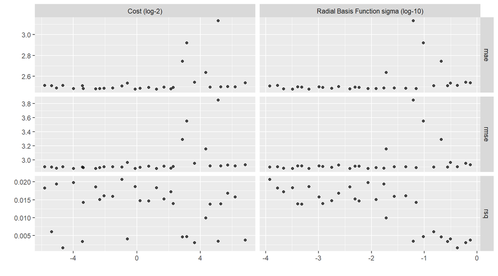

```r
autoplot(svm_grid_fit)
```

```r
mejores_svm <- select_best(svm_grid_fit, metric = "rmse")
cat(sprintf("Mejores HP → cost = %.4f | rbf_sigma = %.6f\n",
            mejores_svm$cost, mejores_svm$rbf_sigma))
```

```
## Mejores HP → cost = 0.9375 | rbf_sigma = 0.000663
```

```r
modelo_svm_final <- finalize_workflow(wf_svm, mejores_svm) %>% fit(data = data_train)
pred_svm_tm <- predict(modelo_svm_final, new_data = data_test)$.pred

cat(sprintf("SVM Radial (tidymodels) → RMSE: %.3f | MAE: %.3f\n",
            Metrics::rmse(y_test, pred_svm_tm),
            Metrics::mae (y_test, pred_svm_tm)))
```

```
## SVM Radial (tidymodels) → RMSE: 2.883 | MAE: 2.467
```

# 9 Módulo 7: Comparativa de variantes SVM con IC Bootstrap

```r
boot_metrics <- function(y, yhat, B = 1000, alpha = 0.05) {
  n <- length(y)
  reps <- replicate(B, {
    idx <- sample.int(n, n, replace = TRUE)
    c(rmse = Metrics::rmse(y[idx], yhat[idx]),
      mae  = Metrics::mae (y[idx], yhat[idx]),
      r2   = 1 - sum((y[idx]-yhat[idx])^2)/sum((y[idx]-mean(y[idx]))^2))
  })
  data.frame(
    metric = c("RMSE","MAE","R2"),
    est    = c(Metrics::rmse(y,yhat), Metrics::mae(y,yhat),
               1 - sum((y-yhat)^2)/sum((y-mean(y))^2)),
    lower  = apply(reps, 1, quantile, probs = alpha/2),
    upper  = apply(reps, 1, quantile, probs = 1-alpha/2)
  )
}

preds_svm <- list(
  "SVM Lineal"       = pred_lineal,
  "SVM Poly"         = pred_poly,
  "SVM Radial base"  = pred_radial_base,
  "SVM Radial e1071" = pred_radial_tuned,
  "SVM Radial tidy"  = pred_svm_tm
)

comparativa_svm <- imap_dfr(preds_svm, function(p, n) {
  m <- boot_metrics(y_test, p); m$Modelo <- n; m
})

comparativa_svm %>%
  mutate(texto = sprintf("%.3f [%.3f, %.3f]", est, lower, upper)) %>%
  select(Modelo, metric, texto) %>%
  pivot_wider(names_from = metric, values_from = texto)
```

| Modelo | RMSE | MAE | R2 |
| --- | --- | --- | --- |
| SVM Lineal | 2.942 [2.761, 3.116] | 2.494 [2.296, 2.704] | -0.016 [-0.064, 0.026] |
| SVM Poly | 3.069 [2.840, 3.288] | 2.560 [2.348, 2.784] | -0.106 [-0.234, 0.008] |
| SVM Radial base | 3.161 [2.939, 3.379] | 2.646 [2.422, 2.860] | -0.173 [-0.311, -0.061] |
| SVM Radial e1071 | 2.889 [2.727, 3.060] | 2.470 [2.290, 2.661] | 0.020 [-0.014, 0.044] |
| SVM Radial tidy | 2.883 [2.723, 3.061] | 2.467 [2.294, 2.664] | 0.024 [-0.009, 0.048] |

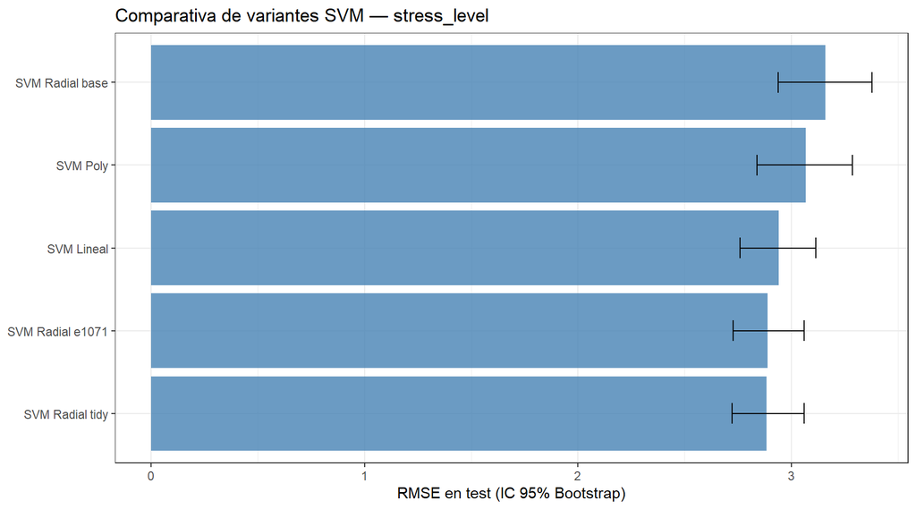

```r
comparativa_svm %>%
  filter(metric == "RMSE") %>%
  ggplot(aes(reorder(Modelo, est), est)) +
  geom_col(fill = "steelblue", alpha = .8) +
  geom_errorbar(aes(ymin = lower, ymax = upper), width = 0.25) +
  coord_flip() +
  labs(x = NULL, y = "RMSE en test (IC 95% Bootstrap)",
       title = "Comparativa de variantes SVM — stress_level") +
  theme_bw()
```

# 10 Módulo 8: Diagnóstico de residuos

```r
rmse_x_svm <- sapply(preds_svm, function(p) Metrics::rmse(y_test, p))
mejor_svm  <- names(which.min(rmse_x_svm))
mejor_pred <- preds_svm[[mejor_svm]]
residuos   <- y_test - mejor_pred

cat("Mejor variante SVM:", mejor_svm, "\n")
```

```
## Mejor variante SVM: SVM Radial tidy
```

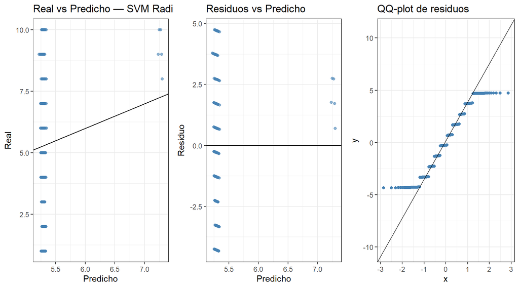

```r
p_a <- ggplot(data.frame(y_test, mejor_pred), aes(mejor_pred, y_test)) +
  geom_point(alpha=.6, color="steelblue") +
  geom_abline(slope=1, intercept=0) +
  labs(x="Predicho", y="Real",
       title=paste("Real vs Predicho —", mejor_svm)) + theme_bw()

p_b <- ggplot(data.frame(mejor_pred, residuos), aes(mejor_pred, residuos)) +
  geom_point(alpha=.6, color="steelblue") +
  geom_hline(yintercept=0, color="black") +
  labs(x="Predicho", y="Residuo", title="Residuos vs Predicho") + theme_bw()

p_c <- ggplot(data.frame(residuos), aes(sample=residuos)) +
  stat_qq(color="steelblue") + stat_qq_line() +
  labs(title="QQ-plot de residuos") + theme_bw()

ggarrange(p_a, p_b, p_c, nrow=1)
```

```r
cat(sprintf("Shapiro-Wilk p = %.4f | t.test(mu=0) p = %.4f\n",
            shapiro.test(residuos)$p.value,
            t.test(residuos)$p.value))
```

```
## Shapiro-Wilk p = 0.0000 | t.test(mu=0) p = 0.5742
```

> **Interpretación:** Si el p-valor de Shapiro < 0.05, los residuos no son normales, lo cual es esperable con una variable objetivo discreta (1–10). Lo importante es que el gráfico de residuos vs predicho no muestre patrones sistemáticos.

# 11 Módulo 9: SVM vs Random Forest vs XGBoost

```r
vars_pred     <- setdiff(names(data_train), "stress_level")
mtry_grid_rf  <- 2:length(vars_pred)
oob_errors_rf <- sapply(mtry_grid_rf, function(m) {
  set.seed(SEED)
  tail(randomForest(stress_level~., data=data_train, mtry=m, ntree=500)$mse, 1)
})
mtry_opt_rf <- mtry_grid_rf[which.min(oob_errors_rf)]
cat("RF mtry óptimo:", mtry_opt_rf, "\n")
```

```
## RF mtry óptimo: 2
```

```r
set.seed(SEED)
modelo_rf_comp <- randomForest(stress_level~., data=data_train,
                               mtry=mtry_opt_rf, ntree=500,
                               nodesize=3, importance=TRUE)
pred_rf_comp <- predict(modelo_rf_comp, newdata=data_test)
```

```r
X_train_xgb <- data_train %>% select(-stress_level) %>% data.matrix()
X_test_xgb  <- data_test  %>% select(-stress_level) %>% data.matrix()
dtrain_xgb  <- xgb.DMatrix(data=X_train_xgb, label=y_train)
dtest_xgb   <- xgb.DMatrix(data=X_test_xgb,  label=y_test)

params_xgb <- list(objective="reg:squarederror", eval_metric="rmse",
                   eta=0.05, max_depth=5, min_child_weight=3,
                   subsample=0.8, colsample_bytree=0.8, gamma=0)
set.seed(SEED)
cv_xgb <- xgb.cv(params=params_xgb, data=dtrain_xgb, nrounds=2000, nfold=5,
                 early_stopping_rounds=50, print_every_n=500, verbose=0)
nr_xgb <- cv_xgb$best_iteration
if (is.null(nr_xgb)||is.na(nr_xgb)||nr_xgb<1)
  nr_xgb <- which.min(cv_xgb$evaluation_log$test_rmse_mean)

set.seed(SEED)
modelo_xgb_comp <- xgb.train(params=params_xgb, data=dtrain_xgb,
                             nrounds=nr_xgb, verbose=0)
pred_xgb_comp <- predict(modelo_xgb_comp, dtest_xgb)
```

```r
preds_todos <- list(
  "SVM Lineal"               = pred_lineal,
  "SVM Radial (e1071 tuned)" = pred_radial_tuned,
  "SVM Radial (tidy)"        = pred_svm_tm,
  "Random Forest"            = pred_rf_comp,
  "XGBoost"                  = pred_xgb_comp
)

comparativa_total <- imap_dfr(preds_todos, function(p, n) {
  m <- boot_metrics(y_test, p); m$Modelo <- n; m
})

comparativa_total %>%
  mutate(texto = sprintf("%.3f [%.3f, %.3f]", est, lower, upper)) %>%
  select(Modelo, metric, texto) %>%
  pivot_wider(names_from=metric, values_from=texto)
```

| Modelo | RMSE | MAE | R2 |
| --- | --- | --- | --- |
| SVM Lineal | 2.942 [2.764, 3.120] | 2.494 [2.295, 2.705] | -0.016 [-0.065, 0.026] |
| SVM Radial (e1071 tuned) | 2.889 [2.726, 3.064] | 2.470 [2.273, 2.662] | 0.020 [-0.011, 0.044] |
| SVM Radial (tidy) | 2.883 [2.712, 3.036] | 2.467 [2.272, 2.654] | 0.024 [-0.009, 0.047] |
| Random Forest | 2.936 [2.769, 3.096] | 2.500 [2.312, 2.697] | -0.012 [-0.061, 0.028] |
| XGBoost | 2.911 [2.759, 3.086] | 2.485 [2.314, 2.686] | 0.005 [-0.029, 0.028] |

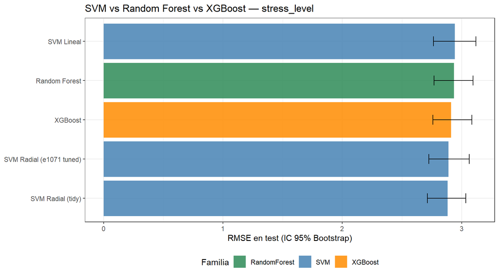

```r
comparativa_total %>%
  filter(metric == "RMSE") %>%
  mutate(familia = case_when(
    grepl("SVM", Modelo)    ~ "SVM",
    grepl("Forest", Modelo) ~ "RandomForest",
    TRUE                    ~ "XGBoost")) %>%
  ggplot(aes(reorder(Modelo, est), est, fill = familia)) +
  geom_col(alpha = .85) +
  geom_errorbar(aes(ymin=lower, ymax=upper), width=0.25) +
  scale_fill_manual(values = c("SVM"="steelblue",
                               "RandomForest"="seagreen",
                               "XGBoost"="darkorange")) +
  coord_flip() +
  labs(x=NULL, y="RMSE en test (IC 95% Bootstrap)",
       title="SVM vs Random Forest vs XGBoost — stress_level",
       fill="Familia") +
  theme_bw() + theme(legend.position="bottom")
```

# 12 Módulo 10: Análisis de Vectores de Soporte

```r
idx_sv  <- svm_radial_tuned$index
sv_data <- data_train[idx_sv, ]
no_sv   <- data_train[-idx_sv, ]

cat(sprintf("Vectores de soporte: %d (%.1f%%)  |  No SV: %d (%.1f%%)\n",
            nrow(sv_data), 100*nrow(sv_data)/nrow(data_train),
            nrow(no_sv),   100*nrow(no_sv)/nrow(data_train)))
```

```
## Vectores de soporte: 904 (94.3%)  |  No SV: 55 (5.7%)
```

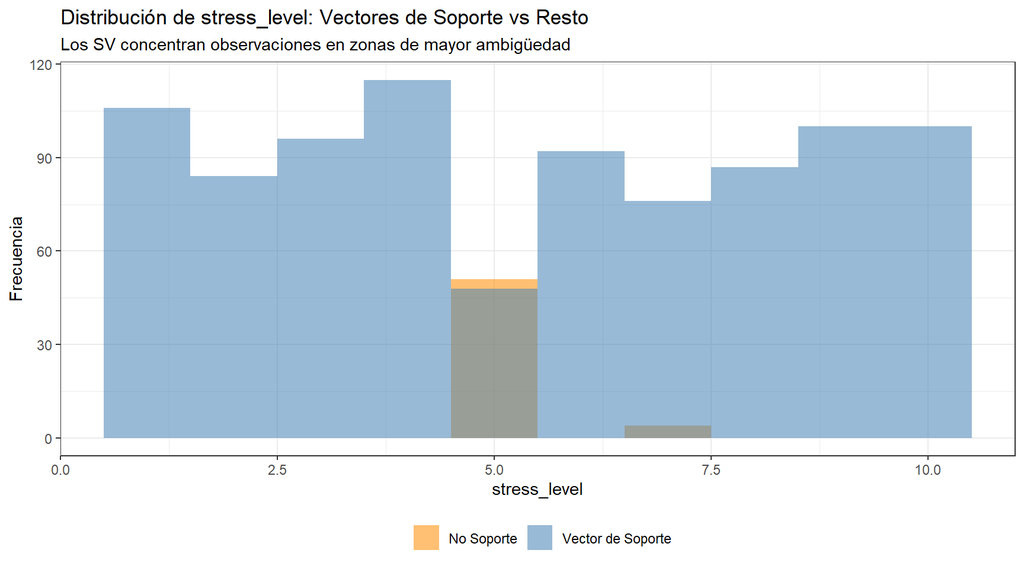

```r
sv_data$tipo <- "Vector de Soporte"
no_sv$tipo   <- "No Soporte"
datos_tipo   <- rbind(sv_data, no_sv)

ggplot(datos_tipo, aes(stress_level, fill=tipo)) +
  geom_histogram(bins=10, position="identity", alpha=0.55) +
  scale_fill_manual(values=c("Vector de Soporte"="steelblue","No Soporte"="darkorange")) +
  labs(title="Distribución de stress_level: Vectores de Soporte vs Resto",
       subtitle="Los SV concentran observaciones en zonas de mayor ambigüedad",
       x="stress_level", y="Frecuencia", fill="") +
  theme_bw() + theme(legend.position="bottom")
```

[figure not shown]

```r
df_sv_cost <- map_dfr(c(0.1, 0.5, 1, 5, 10, 50, 100), function(c_val) {
  set.seed(SEED)
  m <- svm(stress_level~., data=data_train, kernel="radial",
           cost=c_val, gamma=tune_result$best.parameters$gamma, scale=TRUE)
  p <- predict(m, newdata=data_test)
  data.frame(C=c_val, SV_pct=100*m$tot.nSV/nrow(data_train),
             RMSE=Metrics::rmse(y_test,p))
})

p_sv1 <- ggplot(df_sv_cost, aes(log10(C), SV_pct)) +
  geom_line(color="steelblue", linewidth=1) + geom_point(size=3, color="steelblue") +
  labs(title="C ↑  →  SV ↓", x="log10(C)", y="% Vectores de Soporte") + theme_bw()

p_sv2 <- ggplot(df_sv_cost, aes(log10(C), RMSE)) +
  geom_line(color="darkorange", linewidth=1) + geom_point(size=3, color="darkorange") +
  labs(title="RMSE en test según C", x="log10(C)", y="RMSE") + theme_bw()

ggarrange(p_sv1, p_sv2, nrow=1)
```

# 13 Conclusiones

```
## Mejor modelo global: SVM Radial (tidy) (RMSE = 2.883)
```

*Generado con R 4.5.1 · e1071 · tidymodels · ggplot2*